# Taking the S.T.E.P. Towards a Fruitful Future: A Fiscally Grounded Macroeconomic Strategy for Britain

Combining Revenue-Neutral Tax Swapping, Purpose-Driven Welfare, Regional Devolution, and GenAI Productivity to Break the Doom Loop

2026-07-23

← Back to Home

# Beyond the Doom Loop: Reclaiming Economic Hope

For over a decade, Britain’s macroeconomic discourse has been trapped in a self-fulfilling “doom loop.” Stagnant Total Factor Productivity (TFP) growth, rising structural health and disability expenditures, and an escalating sovereign debt-service burden have created a climate of fiscal pessimism. This pessimism feeds higher gilt yields, elevates risk premia, suppresses private investment, and ultimately shrinks the tax base—forcing governments into reactive fiscal tightening that further dampens potential growth.

Breaking out of this vicious cycle requires more than incremental adjustments; it demands a clear, novel, and self-reinforcing policy framework. Enter the **S.T.E.P.** platform (*Switch, Tech, Empower, Purpose*)—a package of four targeted structural reforms designed for rapid short-term implementation (Years 1–3) without triggering uncosted borrowing:

1. **S – Tax Switch for Working Families:** Reverses employment tax squeezes by cutting Personal National Insurance by 2 percentage points, fully funded by equalising the tax treatment of unearned investment and capital income with earned income.
2. **T – Tech & AI Growth Guarantee:** Deploys off-balance-sheet public-private co-investment vehicles via the National Wealth Fund and British Business Bank to match SME digital/AI software adoption and fund applied mathematics short-courses.
3. **E – Empowering Regions (Single-Pot Devolution):** Collapses over 30 fragmented Whitehall competitive bidding pots into single-pot block grants for Combined Mayoral Authorities, funded by rationalising central civil service overheads and active sales of surplus public land assets.
4. **P – Purpose-Driven Welfare (Health-to-Work Gateway):** Replaces duplicate, adversarial assessment processes with a single Health-to-Work gateway tied directly to Integrated Care Boards, substituting low-level cash top-ups with direct-access vouchers and immediate occupational therapy triage.

### The Self-Financing Virtuous Cycle

The core innovation of the S.T.E.P. platform lies in its **inbuilt self-financing design**. By prioritising revenue-neutral tax swaps, Whitehall operational savings, and off-budget asset-backed investment vehicles, the strategy protects public finances in the short term.

Crucially, as confidence returns, a positive feedback loop takes hold. Improved business sentiment crowds in private investment, labour force participation stabilises via health-to-work pathways, and GenAI adoption lifts baseline productivity. The resulting expansion of the real tax base, combined with falling sovereign borrowing yields (*r*<sub>gov</sub>) and narrowing risk premia (*π*<sub>risk</sub>), wards off bond vigilantes and secures a sustainable, long-run fiscal dividend.

# The Macroeconomic Framework: Modelling the Transition

To demonstrate that this positive outcome is structurally sound rather than a collection of random projections, we model the policy platform using an augmented **Solow-Swan supply-side framework** coupled with **recursive sovereign debt accumulation dynamics**.

## Supply-Side Potential Growth

Aggregate output *Y*<sub>*t*</sub> is governed by a Cobb-Douglas production function with labour-augmenting technological progress *A*<sub>*t*</sub>:

*Y*<sub>*t*</sub> = *K*<sub>*t*</sub><sup>*α*</sup>(*A*<sub>*t*</sub>*L*<sub>*t*</sub>)<sup>1 − *α*</sup>

Taking logarithms and time derivatives yields the standard growth accounting identity for potential real GDP growth (*g*<sub>*t*</sub>):

*g*<sub>*t*</sub> = *α**g*<sub>*K*, *t*</sub> + (1 − *α*)(*g*<sub>*A*, *t*</sub> + *g*<sub>*L*, *t*</sub>)

where: * *α* = 0.40 represents the profit share (capital share of aggregate income), calibrated from Penn World Table (PWT) 11.0 national income accounts. * *g*<sub>*A*, *t*</sub> is labour-augmenting Total Factor Productivity (TFP) growth, which accelerates asymptotically from an initial OBR baseline of 0.9% to a GenAI-boosted steady-state target of **2.25%**. * *g*<sub>*L*, *t*</sub> is labour force growth, stabilised at **0.4%–0.5%** via PIP health-to-work reforms. * *g*<sub>*K*, *t*</sub> is capital stock growth, which endogenously converges toward the Solow Balanced Growth Path (BGP) equilibrium: *g*<sub>*K*</sub>* = *g*<sub>*A*</sub> + *g*<sub>*L*</sub> = 2.65%.

## Capital Returns & Public Borrowing Yields

The gross Marginal Product of Capital ($MPK$) and the net private real return (*r*<sub>priv</sub>) are derived from the aggregate capital-output ratio (*K*/*Y* ≈ 4.8, based on PWT 11.0 broad capital stock data):

$$\text{MPK}_t = \alpha \left(\frac{Y_t}{K_t}\right) \approx 0.40 \times \left(\frac{1}{4.8}\right) \approx 8.3\%$$

*r*<sub>priv, *t*</sub> = MPK<sub>*t*</sub> − *δ* = 8.3% − 5.0% = 3.3%

where *δ* = 5.0% is the fixed rate of capital depreciation. Public sector real borrowing yields (*r*<sub>gov, *t*</sub>) are decoupled from private returns via a market risk/convenience wedge (*π*<sub>risk, *t*</sub>):

*r*<sub>priv, *t*</sub> = *r*<sub>gov, *t*</sub> + *π*<sub>risk, *t*</sub>

Anchor-initialised at *r*<sub>gov</sub> = 3.1% in 2027 (matching the 10-year nominal gilt yield of ~5.1% minus 2.0% inflation expectations), *r*<sub>gov</sub> falls toward 1.0% as fiscal credibility is established.

## Recursive Debt Sustainability Mechanics

The sovereign debt-to-GDP ratio (*b*<sub>*t*</sub>) evolves dynamically according to the chained law of motion:

*b*<sub>*t*</sub> = (1 + *r*<sub>gov, *t*</sub> − *g*<sub>*t*</sub>)*b*<sub>*t* − 1</sub> + *p**d*<sub>*t*</sub>

*Δ**b*<sub>*t*</sub> = (*r*<sub>gov, *t*</sub> − *g*<sub>*t*</sub>)*b*<sub>*t* − 1</sub> + *p**d*<sub>*t*</sub>

where *p**d*<sub>*t*</sub> is the primary deficit ratio. Defining the **Sustainability Gap** as *g*<sub>*t*</sub> − *r*<sub>gov, *t*</sub>: * **Dynamic Stability (*g* > *r*<sub>gov</sub>):** The economy generates a positive growth dividend that naturally erodes the debt ratio, allowing structural primary surpluses (*p**d* < 0) to accelerate debt reduction.

# Simulation Results & Horizon Projections

The simulation is initialised using official Office for Budget Responsibility (OBR) baseline figures for 2025/26 (*b*<sub>2026</sub> = 94.0%, initial primary deficit $= 1.4%$, debt interest $= 2.9%$, GDP growth $= 1.5%$). From 2028 onward, the S.T.E.P. platform structural effects transition the UK economy toward its long-run steady state.

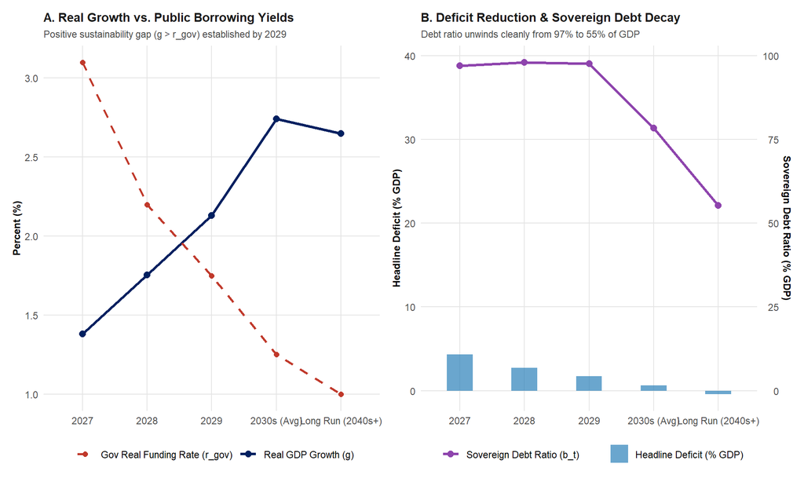